# Biostat 212a Homework 6

Due Mar 21, 2025 @ 11:59PM

Author

Wenqiang Ge UID:106371961

Published

March 19, 2025

Load R libraries.

```r
library(tidyverse)
library(tidymodels)
library(readr)
library(tswge)
library(ggplot2)

acfdf <- function(vec) {
    vacf <- acf(vec, plot = F)
    with(vacf, data.frame(lag, acf))
}

ggacf <- function(vec) {
    ac <- acfdf(vec)
    ggplot(data = ac, aes(x = lag, y = acf)) + geom_hline(aes(yintercept = 0)) +
        geom_segment(mapping = aes(xend = lag, yend = 0))
}

tplot <- function(vec) {
    df <- data.frame(X = vec, t = seq_along(vec))
    ggplot(data = df, aes(x = t, y = X)) + geom_line()
}
```

## 1 New York Stock Exchange (NYSE) data (1962-1986) (140 pts)

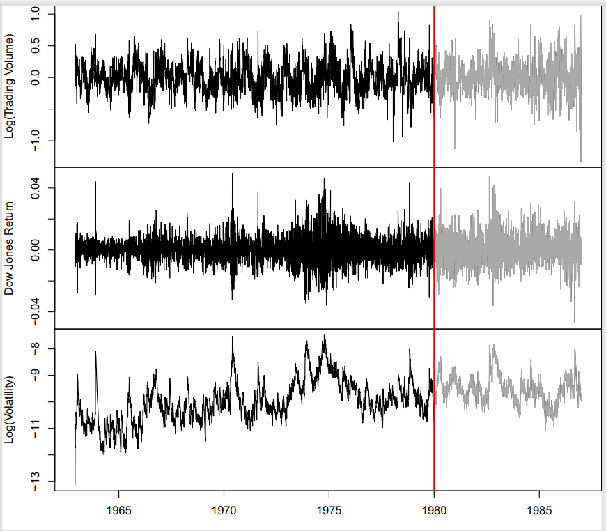

Figure 1: Historical trading statistics from the New York Stock Exchange. Daily values of the normalized log trading volume, DJIA return, and log volatility are shown for a 24-year period from 1962-1986. We wish to predict trading volume on any day, given the history on all earlier days. To the left of the red bar (January 2, 1980) is training data, and to the right test data.

The [`NYSE.csv`](https://raw.githubusercontent.com/ucla-biostat-212a/2024winter/master/slides/data/NYSE.csv) file contains three daily time series from the New York Stock Exchange (NYSE) for the period Dec 3, 1962-Dec 31, 1986 (6,051 trading days).

- `Log trading volume` ($v_t$): This is the fraction of all outstanding shares that are traded on that day, relative to a 100-day moving average of past turnover, on the log scale.
- `Dow Jones return` ($r_t$): This is the difference between the log of the Dow Jones Industrial Index on consecutive trading days.
- `Log volatility` ($z_t$): This is based on the absolute values of daily price movements.

```r
# Read in NYSE data from url

url = "https://raw.githubusercontent.com/ucla-biostat-212a/2025winter/master/slides/data/NYSE.csv"
NYSE <- read_csv(url)

NYSE
```

```
# A tibble: 6,051 × 6
   date       day_of_week DJ_return log_volume log_volatility train
   <date>     <chr>           <dbl>      <dbl>          <dbl> <lgl>
 1 1962-12-03 mon         -0.00446     0.0326           -13.1 TRUE
 2 1962-12-04 tues         0.00781     0.346            -11.7 TRUE
 3 1962-12-05 wed          0.00384     0.525            -11.7 TRUE
 4 1962-12-06 thur        -0.00346     0.210            -11.6 TRUE
 5 1962-12-07 fri          0.000568    0.0442           -11.7 TRUE
 6 1962-12-10 mon         -0.0108      0.133            -10.9 TRUE
 7 1962-12-11 tues         0.000124   -0.0115           -11.0 TRUE
 8 1962-12-12 wed          0.00336     0.00161          -11.0 TRUE
 9 1962-12-13 thur        -0.00330    -0.106            -11.0 TRUE
10 1962-12-14 fri          0.00447    -0.138            -11.0 TRUE
# ℹ 6,041 more rows
```

The **autocorrelation** at lag $\ell$ is the correlation of all pairs $(v_t, v_{t-\ell})$ that are $\ell$ trading days apart. These sizable correlations give us confidence that past values will be helpful in predicting the future.

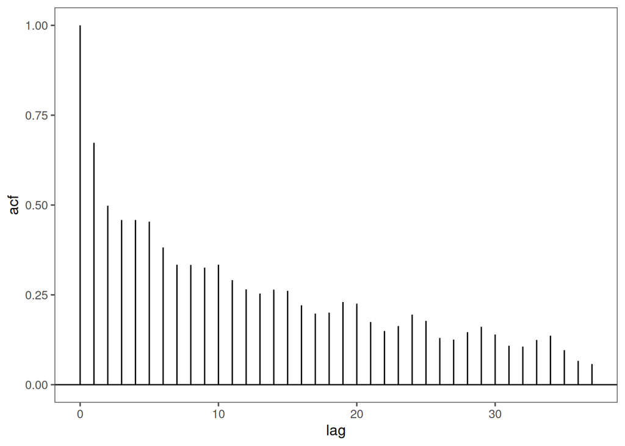

Figure 2: The autocorrelation function for log volume. We see that nearby values are fairly strongly correlated, with correlations above 0.2 as far as 20 days apart.

```r
ggacf(NYSE$log_volume) + ggthemes::theme_few()
```

Do a similar plot for (1) the correlation between $v_t$ and lag $\ell$ `Dow Jones return` $r_{t-\ell}$ and (2) correlation between $v_t$ and lag $\ell$ `Log volatility` $z_{t-\ell}$.

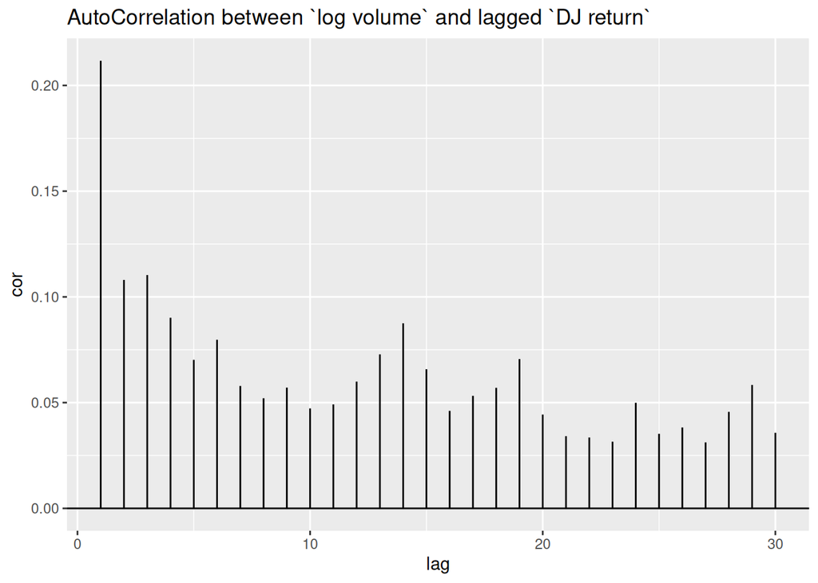

```r
seq(1, 30) %>%
  map(function(x) {cor(NYSE$log_volume , lag(NYSE$DJ_return, x), use = "pairwise.complete.obs")}) %>%
  unlist() %>%
  tibble(lag = 1:30, cor = .) %>%
  ggplot(aes(x = lag, y = cor)) +
  geom_hline(aes(yintercept = 0)) +
  geom_segment(mapping = aes(xend = lag, yend = 0)) +
  ggtitle("AutoCorrelation between `log volume` and lagged `DJ return`")
```

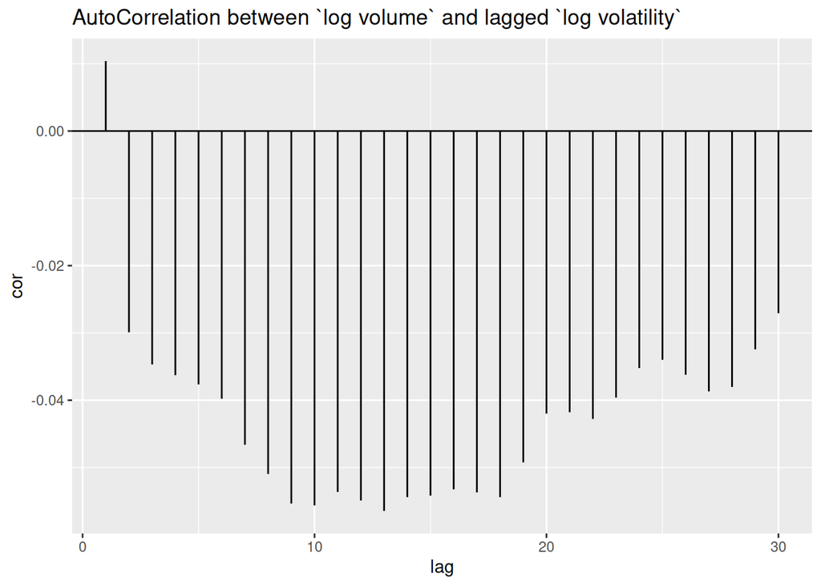

```r
seq(1, 30) %>%
  map(function(x) {cor(NYSE$log_volume , lag(NYSE$log_volatility, x), use = "pairwise.complete.obs")}) %>%
  unlist() %>%
  tibble(lag = 1:30, cor = .) %>%
  ggplot(aes(x = lag, y = cor)) +
  geom_hline(aes(yintercept = 0)) +
  geom_segment(mapping = aes(xend = lag, yend = 0)) +
  ggtitle("AutoCorrelation between `log volume` and lagged `log volatility`")
```

### 1.1 Project goal

Our goal is to forecast daily `Log trading volume`, using various machine learning algorithms we learnt in this class.

The data set is already split into train (before Jan 1st, 1980, $n_{\text{train}} = 4,281$) and test (after Jan 1st, 1980, $n_{\text{test}} = 1,770$) sets.

In general, we will tune the lag $L$ to acheive best forecasting performance. In this project, we would fix $L=5$. That is we always use the previous five trading days’ data to forecast today’s `log trading volume`.

Pay attention to the nuance of splitting time series data for cross validation. Study and use the [`time-series`](https://www.tidymodels.org/learn/models/time-series/) functionality in tidymodels. Make sure to use the same splits when tuning different machine learning algorithms.

Use the $R^2$ between forecast and actual values as the cross validation and test evaluation criterion.

### 1.2 Baseline method (20 pts)

We use the straw man (use yesterday’s value of `log trading volume` to predict that of today) as the baseline method. Evaluate the $R^2$ of this method on the test data.

Solution:

```r
# Lag: look back L trading days
L = 5

for(i in seq(1, L)) {
  NYSE <- NYSE %>%
    mutate(!!paste("DJ_return_lag", i, sep = "") := lag(NYSE$DJ_return, i),
           !!paste("log_volume_lag", i, sep = "") := lag(NYSE$log_volume, i),
           !!paste("log_volatility_lag", i, sep = "") := lag(NYSE$log_volatility, i))
}

NYSE <-   NYSE |>
  na.omit()

print(NYSE , width = Inf)
```

```
# A tibble: 6,046 × 21
   date       day_of_week DJ_return log_volume log_volatility train
   <date>     <chr>           <dbl>      <dbl>          <dbl> <lgl>
 1 1962-12-10 mon         -0.0108      0.133            -10.9 TRUE
 2 1962-12-11 tues         0.000124   -0.0115           -11.0 TRUE
 3 1962-12-12 wed          0.00336     0.00161          -11.0 TRUE
 4 1962-12-13 thur        -0.00330    -0.106            -11.0 TRUE
 5 1962-12-14 fri          0.00447    -0.138            -11.0 TRUE
 6 1962-12-17 mon         -0.00402    -0.0496           -11.0 TRUE
 7 1962-12-18 tues        -0.00832    -0.0434           -10.7 TRUE
 8 1962-12-19 wed          0.0107      0.0536           -10.4 TRUE
 9 1962-12-20 thur         0.00239     0.105            -10.5 TRUE
10 1962-12-21 fri         -0.00330    -0.0890           -10.5 TRUE
   DJ_return_lag1 log_volume_lag1 log_volatility_lag1 DJ_return_lag2
            <dbl>           <dbl>               <dbl>          <dbl>
```

[output cut: 47 more lines]

```r
# Split the training and tesing set
NYSE_train <- NYSE |>
  filter(train == 'TRUE') |>
  select(-train) |>
  drop_na()

NYSE_test <- NYSE |>
  filter(train == 'FALSE') |>
  select(-train)|>
  drop_na()

dim(NYSE_train)
```

```
[1] 4276   20
```

```r
dim(NYSE_test)
```

```
[1] 1770   20
```

```r
library(yardstick)

r2_test_strawman <- rsq_vec(NYSE_test$log_volume,
                            lag(NYSE_test$log_volume,
                                1)) |>
  round(2)

print(paste("Straw man test R2: ", r2_test_strawman))
```

```
[1] "Straw man test R2:  0.35"
```

### 1.3 Autoregression (AR) forecaster (30 pts)

- Let
  $$y = \begin{pmatrix} v_{L+1} \\ v_{L+2} \\ v_{L+3} \\ \vdots \\ v_T \end{pmatrix}, \quad M = \begin{pmatrix}
  1 & v_L & v_{L-1} & \cdots & v_1 \\
  1 & v_{L+1} & v_{L} & \cdots & v_2 \\
  \vdots & \vdots & \vdots & \ddots & \vdots \\
  1 & v_{T-1} & v_{T-2} & \cdots & v_{T-L}
  \end{pmatrix}.$$
- Fit an ordinary least squares (OLS) regression of $y$ on $M$, giving
  $$\hat v_t = \hat \beta_0 + \hat \beta_1 v_{t-1} + \hat \beta_2 v_{t-2} + \cdots + \hat \beta_L v_{t-L},$$
  known as an **order-**$L$ autoregression model or **AR(**$L$).
- Tune AR(5) with elastic net (lasso + ridge) regularization using all 3 features on the training data, and evaluate the test performance.
- Hint: [Workflow: Lasso](https://ucla-biostat-212a.github.io/2025winter/slides/06-modelselection/workflow_lasso.html) is a good starting point.

Solution:

```r
set.seed(212)
# Load required libraries
library(glmnet)
library(dplyr)
library(tidymodels)
en_recipe <-
  recipe(log_volume ~ ., data = NYSE_train) |>
  step_dummy(all_nominal(), -all_outcomes()) |>
  step_normalize(all_numeric_predictors(), -all_outcomes()) |>
  step_zv(all_predictors()) |>
  step_naomit(all_predictors())  |>
  step_rm(date) |>
  step_indicate_na()
```

```r
en_mod <-
  linear_reg(penalty = tune(),
             mixture = tune()) |>
  set_engine("glmnet")

en_mod
```

```
Linear Regression Model Specification (regression)

Main Arguments:
  penalty = tune()
  mixture = tune()

Computational engine: glmnet
```

```r
en_wf <-
  workflow() |>
  add_model(en_mod) |>
  add_recipe(en_recipe)
```

```r
month_folds <- NYSE_train |>
  sliding_period(
    date,
    "month",
    lookback = Inf,
    skip = 4)
```

```r
en_grid <-
  grid_regular(penalty(range = c(-8, -7),
                       trans = log10_trans()),
               mixture(),
               levels = c(4,5))
en_grid
```

```
# A tibble: 20 × 2
        penalty mixture
          <dbl>   <dbl>
 1 0.00000001      0
 2 0.0000000215    0
 3 0.0000000464    0
 4 0.0000001       0
 5 0.00000001      0.25
 6 0.0000000215    0.25
 7 0.0000000464    0.25
 8 0.0000001       0.25
 9 0.00000001      0.5
10 0.0000000215    0.5
11 0.0000000464    0.5
12 0.0000001       0.5
13 0.00000001      0.75
14 0.0000000215    0.75
15 0.0000000464    0.75
16 0.0000001       0.75
17 0.00000001      1
18 0.0000000215    1
19 0.0000000464    1
20 0.0000001       1
```

```r
en_fit <- tune_grid(en_wf,
                    resamples = month_folds,
                    grid = en_grid)
```

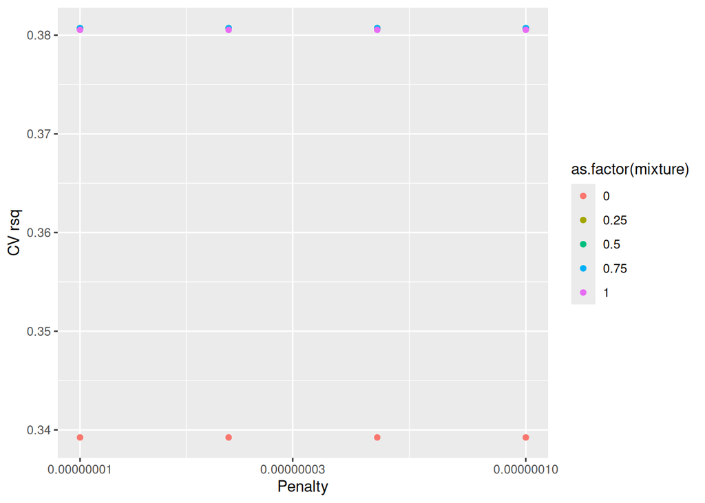

```r
en_fit |>
  collect_metrics() |>
  filter(.metric == "rsq") |>
  ggplot(mapping = aes(x = penalty, y = mean,
                       colour = as.factor(mixture))) +
  geom_point() +
  labs(x = "Penalty", y = "CV rsq") +
  scale_x_log10(labels = scales::label_number())
```

```r
en_fit |>
  show_best()
```

```
# A tibble: 5 × 8
       penalty mixture .metric .estimator  mean     n std_err .config
         <dbl>   <dbl> <chr>   <chr>      <dbl> <int>   <dbl> <chr>
1 0.00000001      0.5  rmse    standard   0.133   200 0.00287 Preprocessor1_Mod…
2 0.0000000215    0.5  rmse    standard   0.133   200 0.00287 Preprocessor1_Mod…
3 0.0000000464    0.5  rmse    standard   0.133   200 0.00287 Preprocessor1_Mod…
4 0.0000001       0.5  rmse    standard   0.133   200 0.00287 Preprocessor1_Mod…
5 0.00000001      0.75 rmse    standard   0.133   200 0.00287 Preprocessor1_Mod…
```

```r
best_en <- en_fit |>
  select_best(metric = "rsq")
```

```r
cv_results <- en_fit |>
  collect_metrics() |>
  filter(.metric == "rsq") |>
  arrange(desc(mean))

print(paste("Straw man CV R2:", round(cv_results$mean[1], 2)))
```

```
[1] "Straw man CV R2: 0.38"
```

```r
#Final model
final_wf <- en_wf |>
  finalize_workflow(best_en)

final_fit <- final_wf |>
  fit(data = NYSE_train)
```

```r
predictions <- predict(final_fit, new_data = NYSE_test) |>
  bind_cols(NYSE_test)

metrics <- predictions %>%
  metrics(truth = log_volume, estimate = .pred)
metrics
```

```
# A tibble: 3 × 3
  .metric .estimator .estimate
  <chr>   <chr>          <dbl>
1 rmse    standard       0.160
2 rsq     standard       0.554
3 mae     standard       0.116
```

```r
rsq_value <- metrics %>%
  filter(.metric == "rsq") %>%
  pull(.estimate)

print(paste("Straw man test R2: ", round(rsq_value,2)))
```

```
[1] "Straw man test R2:  0.55"
```

### 1.4 Random forest forecaster (30pts)

- Use the same features as in AR($L$) for the random forest. Tune the random forest and evaluate the test performance.
- Hint: [Workflow: Random Forest for Prediction](https://ucla-biostat-212a.github.io/2025winter/slides/08-tree/workflow_rf_reg.html) is a good starting point.

Solution:

```r
rf_recipe <-
  recipe(log_volume ~ ., data = NYSE_train) |>
  step_zv(all_predictors()) |>
  step_naomit(all_predictors())  |>
  step_rm(date) |>
  step_indicate_na()
rf_recipe
```

```r
rf_mod <-
  rand_forest(
    mode = "regression",
    mtry = tune(),
    trees = tune()
  ) |>
  set_engine("ranger")
rf_mod
```

```
Random Forest Model Specification (regression)

Main Arguments:
  mtry = tune()
  trees = tune()

Computational engine: ranger
```

```r
rf_wf <- workflow() |>
  add_recipe(rf_recipe) |>
  add_model(rf_mod)
rf_wf
```

```
══ Workflow ════════════════════════════════════════════════════════════════════
Preprocessor: Recipe
Model: rand_forest()

── Preprocessor ────────────────────────────────────────────────────────────────
4 Recipe Steps

• step_zv()
• step_naomit()
• step_rm()
• step_indicate_na()

── Model ───────────────────────────────────────────────────────────────────────
Random Forest Model Specification (regression)

Main Arguments:
  mtry = tune()
  trees = tune()

Computational engine: ranger
```

```r
set.seed(212)
rf_grid <- grid_regular(
  trees(range = c(100L, 300L)),
  mtry(range = c(3L, 5L)),
  levels = 3
)
```

```r
month_folds <- NYSE_train |>
  sliding_period(
    date,
    "month",
    lookback = Inf,
    skip = 4)
```

```r
rf_fit <- rf_wf |>
  tune_grid(
    resamples = month_folds,
    grid = rf_grid,
    metrics = metric_set(rmse, rsq)
  )
```

```
# A tibble: 18 × 8
    mtry trees .metric .estimator  mean     n std_err .config
   <int> <int> <chr>   <chr>      <dbl> <int>   <dbl> <chr>
 1     3   100 rmse    standard   0.142   200 0.00311 Preprocessor1_Model1
 2     3   100 rsq     standard   0.338   200 0.0146  Preprocessor1_Model1
 3     3   200 rmse    standard   0.142   200 0.00309 Preprocessor1_Model2
 4     3   200 rsq     standard   0.340   200 0.0149  Preprocessor1_Model2
 5     3   300 rmse    standard   0.142   200 0.00308 Preprocessor1_Model3
 6     3   300 rsq     standard   0.342   200 0.0148  Preprocessor1_Model3
 7     4   100 rmse    standard   0.140   200 0.00301 Preprocessor1_Model4
 8     4   100 rsq     standard   0.343   200 0.0148  Preprocessor1_Model4
 9     4   200 rmse    standard   0.140   200 0.00300 Preprocessor1_Model5
10     4   200 rsq     standard   0.345   200 0.0147  Preprocessor1_Model5
11     4   300 rmse    standard   0.140   200 0.00299 Preprocessor1_Model6
12     4   300 rsq     standard   0.346   200 0.0147  Preprocessor1_Model6
13     5   100 rmse    standard   0.139   200 0.00291 Preprocessor1_Model7
14     5   100 rsq     standard   0.343   200 0.0146  Preprocessor1_Model7
15     5   200 rmse    standard   0.139   200 0.00293 Preprocessor1_Model8
16     5   200 rsq     standard   0.345   200 0.0146  Preprocessor1_Model8
17     5   300 rmse    standard   0.139   200 0.00293 Preprocessor1_Model9
18     5   300 rsq     standard   0.348   200 0.0147  Preprocessor1_Model9
```

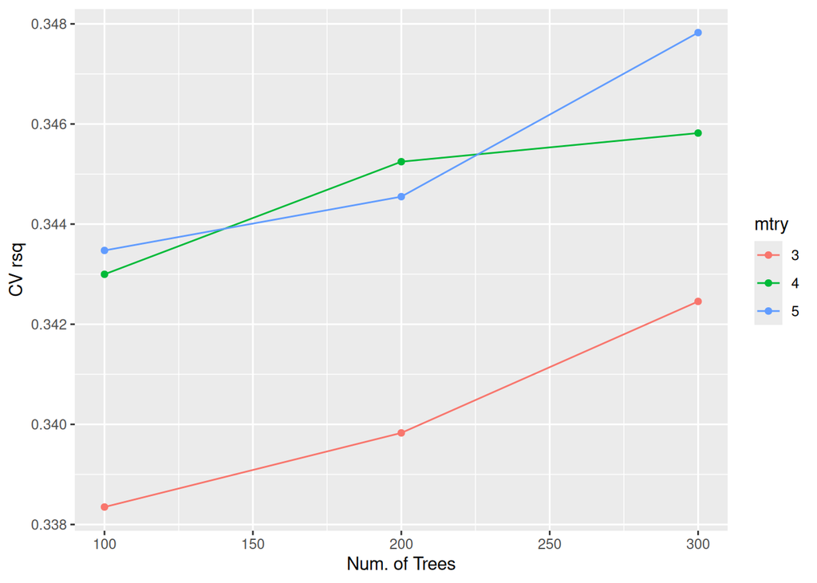

```r
set.seed(212)
rf_fit |>
  collect_metrics() |>
  print(width = Inf) |>
  filter(.metric == "rsq") |>
  mutate(mtry = as.factor(mtry)) |>
  ggplot(mapping = aes(x = trees, y = mean, color = mtry)) +
  geom_point() +
  geom_line() +
  labs(x = "Num. of Trees", y = "CV rsq")
```

```r
rf_fit |>
  show_best()
```

```
# A tibble: 5 × 8
   mtry trees .metric .estimator  mean     n std_err .config
  <int> <int> <chr>   <chr>      <dbl> <int>   <dbl> <chr>
1     5   300 rmse    standard   0.139   200 0.00293 Preprocessor1_Model9
2     5   100 rmse    standard   0.139   200 0.00291 Preprocessor1_Model7
3     5   200 rmse    standard   0.139   200 0.00293 Preprocessor1_Model8
4     4   300 rmse    standard   0.140   200 0.00299 Preprocessor1_Model6
5     4   100 rmse    standard   0.140   200 0.00301 Preprocessor1_Model4
```

```r
best_rf <- rf_fit |>
  select_best(metric = "rsq")
best_rf
```

```
# A tibble: 1 × 3
   mtry trees .config
  <int> <int> <chr>
1     5   300 Preprocessor1_Model9
```

```r
cv_results <- rf_fit |>
  collect_metrics() |>
  filter(.metric == "rsq") |>
  arrange(desc(mean))

print(paste("Straw man CV R2:", round(cv_results$mean[1], 2)))
```

```
[1] "Straw man CV R2: 0.35"
```

```r
#Final model
final_wf <- rf_wf |>
  finalize_workflow(best_rf)

final_fit <- final_wf |>
  fit(data = NYSE_train)
```

```r
predictions <- predict(final_fit, new_data = NYSE_test) |>
  bind_cols(NYSE_test)

metrics <- predictions |>
  metrics(truth = log_volume, estimate = .pred)
```

```r
rsq_value <- metrics %>%
  filter(.metric == "rsq") %>%
  pull(.estimate)
print(paste("Straw man test R2: ", round(rsq_value,2)))
```

```
[1] "Straw man test R2:  0.51"
```

### 1.5 Boosting forecaster (30pts)

- Use the same features as in AR($L$) for the boosting. Tune the boosting algorithm and evaluate the test performance.
- Hint: [Workflow: Boosting tree for Prediction](https://ucla-biostat-212a.github.io/2025winter/slides/08-tree/workflow_boosting_reg.html) is a good starting point.

Solution:

```r
gb_recipe <-
  recipe(log_volume ~ ., data = NYSE_train) |>
  step_dummy(all_nominal(), -all_outcomes()) |>
  step_zv(all_predictors()) |>
  step_naomit(all_predictors())  |>
  step_rm(date) |>
  step_indicate_na()
gb_recipe
```

```r
gb_mod <-
  boost_tree(
    mode = "regression",
    trees = 100,
    tree_depth = tune(),
    learn_rate = tune()
  ) %>%
  set_engine("xgboost")

gb_wf <- workflow() %>%
  add_recipe(gb_recipe) %>%
  add_model(gb_mod)
gb_wf
```

```
══ Workflow ════════════════════════════════════════════════════════════════════
Preprocessor: Recipe
Model: boost_tree()

── Preprocessor ────────────────────────────────────────────────────────────────
5 Recipe Steps

• step_dummy()
• step_zv()
• step_naomit()
• step_rm()
• step_indicate_na()

── Model ───────────────────────────────────────────────────────────────────────
Boosted Tree Model Specification (regression)

Main Arguments:
  trees = 100
  tree_depth = tune()
  learn_rate = tune()

Computational engine: xgboost
```

```r
set.seed(212)
bt_grid <- grid_regular(
  tree_depth(range = c(1L, 3L)),
  learn_rate(range = c(-2, -0.5),
             trans = log10_trans()),
  levels = 3
  )
```

```r
month_folds <- NYSE_train|>
  sliding_period(
    date,
    "month",
    lookback = Inf,
    skip = 4)
```

```
# A tibble: 18 × 8
   tree_depth learn_rate .metric .estimator  mean     n std_err
        <int>      <dbl> <chr>   <chr>      <dbl> <int>   <dbl>
 1          1     0.01   rmse    standard   0.257   200 0.00561
 2          1     0.01   rsq     standard   0.203   200 0.0120
 3          2     0.01   rmse    standard   0.250   200 0.00501
 4          2     0.01   rsq     standard   0.239   200 0.0126
 5          3     0.01   rmse    standard   0.247   200 0.00480
 6          3     0.01   rsq     standard   0.270   200 0.0133
 7          1     0.0562 rmse    standard   0.150   200 0.00323
 8          1     0.0562 rsq     standard   0.289   200 0.0136
 9          2     0.0562 rmse    standard   0.141   200 0.00298
10          2     0.0562 rsq     standard   0.341   200 0.0147
11          3     0.0562 rmse    standard   0.137   200 0.00287
12          3     0.0562 rsq     standard   0.371   200 0.0154
```

[output cut: 26 more lines]

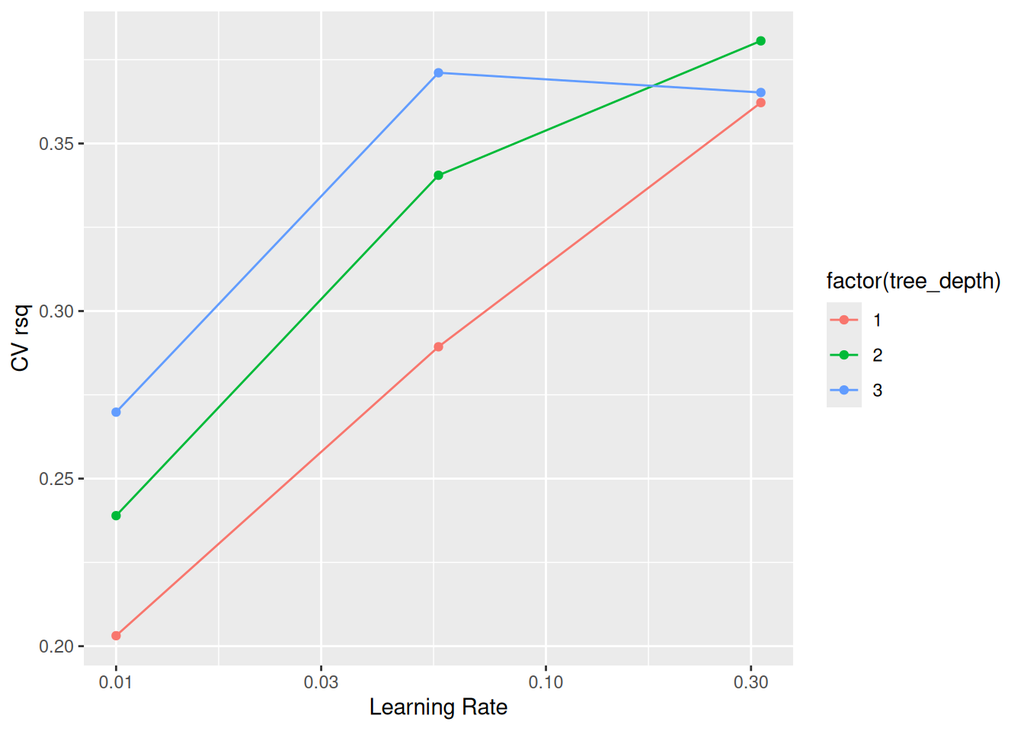

```r
set.seed(212)
gb_fit <- gb_wf %>%
  tune_grid(
    resamples = month_folds,
    grid = bt_grid,
    metrics = metric_set(rmse, rsq)
    )

gb_fit |>
  collect_metrics() |>
  print(width = Inf) |>
  filter(.metric == "rsq") |>
  ggplot(mapping = aes(x = learn_rate, y = mean, color = factor(tree_depth))) +
  geom_point() +
  geom_line() +
  labs(x = "Learning Rate", y = "CV rsq") +
  scale_x_log10()
```

```r
gb_fit |>
  show_best()
```

```
# A tibble: 5 × 8
  tree_depth learn_rate .metric .estimator  mean     n std_err .config
       <int>      <dbl> <chr>   <chr>      <dbl> <int>   <dbl> <chr>
1          2     0.316  rmse    standard   0.136   200 0.00284 Preprocessor1_Mo…
2          3     0.0562 rmse    standard   0.137   200 0.00287 Preprocessor1_Mo…
3          1     0.316  rmse    standard   0.137   200 0.00287 Preprocessor1_Mo…
4          3     0.316  rmse    standard   0.139   200 0.00286 Preprocessor1_Mo…
5          2     0.0562 rmse    standard   0.141   200 0.00298 Preprocessor1_Mo…
```

```r
best_gb <- gb_fit |>
  select_best(metric = "rsq")
best_gb
```

```
# A tibble: 1 × 3
  tree_depth learn_rate .config
       <int>      <dbl> <chr>
1          2      0.316 Preprocessor1_Model8
```

```r
cv_results <- gb_fit |>
  collect_metrics() |>
  filter(.metric == "rsq") |>
  arrange(desc(mean))

print(paste("Straw man CV R2:", round(cv_results$mean[1], 2)))
```

```
[1] "Straw man CV R2: 0.38"
```

```r
#Final model
final_wf <- gb_wf |>
  finalize_workflow(best_gb)
```

```r
final_fit <- final_wf |>
  fit(data = NYSE_train)

predictions <- predict(final_fit,
                       new_data = NYSE_test) |>
  bind_cols(NYSE_test)

metrics <- predictions |>
  metrics(truth = log_volume, estimate = .pred)
metrics
```

```
# A tibble: 3 × 3
  .metric .estimator .estimate
  <chr>   <chr>          <dbl>
1 rmse    standard       0.163
2 rsq     standard       0.541
3 mae     standard       0.117
```

```r
rsq_value <- metrics %>%
  filter(.metric == "rsq") %>%
  pull(.estimate)
print(paste("Straw man test R2: ", round(rsq_value,2)))
```

```
[1] "Straw man test R2:  0.54"
```

### 1.6 Summary (30pts)

Your score for this question is largely determined by your final test performance.

Summarize the performance of different machine learning forecasters in the following format.

| Method | CV $R^2$ | Test $R^2$ |  |
| --- | --- | --- | --- |
| Baseline | NA | 0.35 |  |
| AR(5) | 0.38 | 0.55 |  |
| Random Forest | 0.35 | 0.51 |  |
| Boosting | 0.38 | 0.54 |  |

Solution:

In this time series forecasting task, different models demonstrated varying levels of generalization ability $(CV\ R^2)$ and predictive performance $(Test\ R^2)$.

**Baseline** relied solely on the previous day’s trading volume, lacking generalization capability, and achieved a test $R^2$ of $0.35$, serving as a benchmark.

**AR(5)** utilized data from the past five days for predictions, showing moderate generalization ability $(CV\ R^2 = 0.38)$. Its $Test\ R^2=0.55$ suggests that it effectively captured short-term trends and improved upon the baseline.

**Random Forest (RF)** exhibited slightly lower generalization ability than AR(5) $(CV\ R^2=0.35)$ and achieved a $Test\ R^2=0.51$. This indicates that while RF was able to leverage time-series patterns, it did not significantly surpass the linear AR(5) model.

Overall, AR(5) and Boosting provided the highest generalization, with AR(5) showing better predictive accuracy across different datasets.

## 2 ISL Exercise 12.6.13 (90 pts)

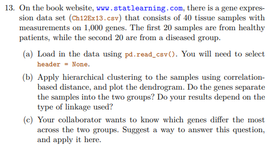

(a)

```r
library(ISLR2)
library(tidyverse)
gene <-
  read.csv("https://www.statlearning.com/s/Ch12Ex13.csv",
           header=FALSE)
colnames(gene) <- c(paste0("healthy", 1:20),
                    paste0("diseased", 1:20))
head(gene, 10)
```

```
      healthy1   healthy2   healthy3   healthy4   healthy5   healthy6
1  -0.96193340  0.4418028 -0.9750051  1.4175040  0.8188148  0.3162937
2  -0.29252570 -1.1392670  0.1958370 -1.2811210 -0.2514393  2.5119970
3   0.25878820 -0.9728448  0.5884858 -0.8002581 -1.8203980 -2.0589240
4  -1.15213200 -2.2131680 -0.8615249  0.6309253  0.9517719 -1.1657240
5   0.19578280  0.5933059  0.2829921  0.2471472  1.9786680 -0.8710180
6   0.03012394 -0.6910143 -0.4034258 -0.7298590 -0.3640986  1.1253490
7   0.08541773 -1.1130540 -0.6779688 -0.5629290  0.9381944  0.1188091
8   1.11661000  1.3417000  0.1032784  0.3909632 -1.9274910  0.4516918
9  -1.21885700 -1.2772790 -0.5589246 -1.3444930  1.1591150 -1.5010440
10  1.26736900 -0.9183490 -1.2535000 -1.0671140 -0.2406378  1.1638890
      healthy7    healthy8    healthy9  healthy10  healthy11  healthy12
1  -0.02496682 -0.06396600  0.03149702 -0.3503106 -0.7227299 -0.2819547
2  -0.92220620  0.05954277 -1.40964500 -0.6567122 -0.1157652  0.8259783
3  -0.06476437  1.59212400 -0.17311700 -0.1210874 -0.1875790 -1.5001630
```

[output cut: 62 more lines]

### 2.1 12.6.13 (b) (30 pts)

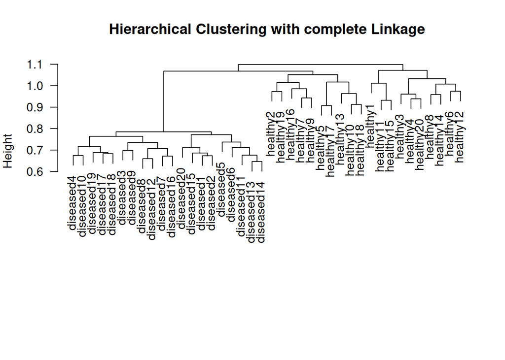

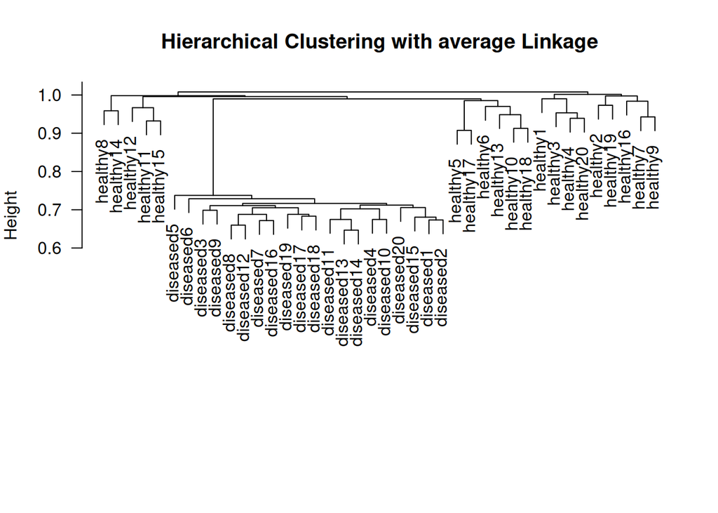

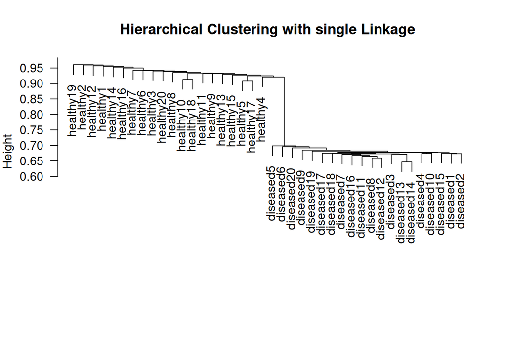

```r
# Compute correlation-based distance matrix
dist_matrix <- as.dist(1 - cor(gene))

# Perform hierarchical clustering with different linkage methods and plot separately
methods <- c("complete", "average", "single")

for (method in methods) {
  hc <- hclust(dist_matrix, method = method)

  # Adjust margins to ensure enough space for labels
  par(mar = c(8, 4, 4, 2))  # Increase bottom margin

  # Plot the dendrogram
  plot(hc, main = paste("Hierarchical Clustering with", method, "Linkage"),
       sub = "", xlab = "", cex = 1, las = 2)  # Reduce font size & rotate labels
}
```

The hierarchical clustering results indicate that the ability to separate healthy and diseased samples depends on the linkage method used. The genes separate the samples into the two groups.

Average linkage shows moderate separation, but with more mixing between the two groups.

These results suggest that while gene expression patterns contribute to distinguishing the two groups, the effectiveness of clustering is strongly influenced by the chosen linkage method.

### 2.2 PCA and UMAP (30 pts)

PCA

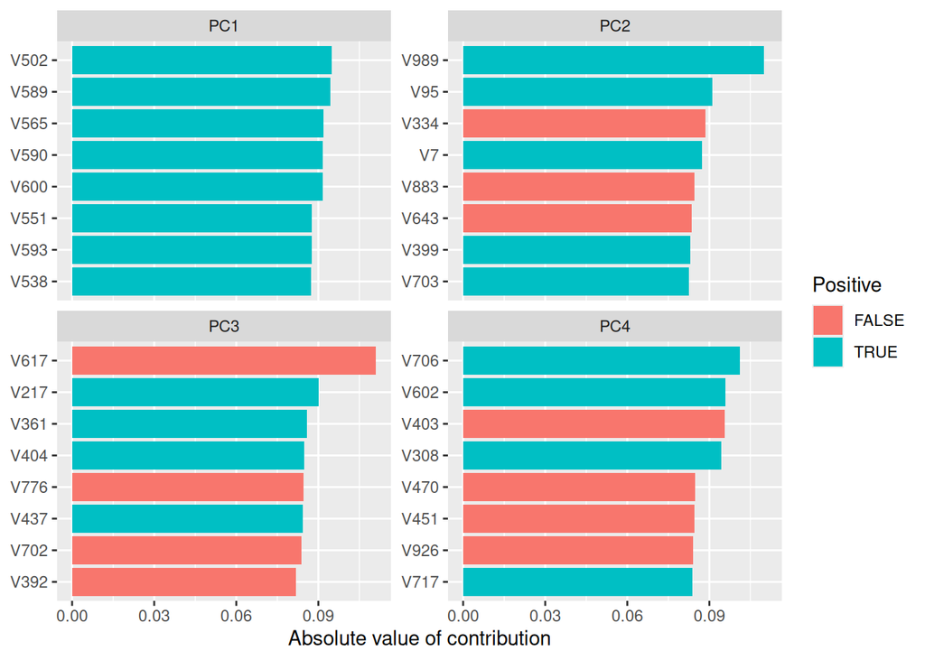

```r
library(tidymodels)
transposed_gene <- as_tibble(t(gene)) |>
  mutate(group = rep(c("healthy", "diseased"), each = 20))
pca_rec <- recipe(~., data = transposed_gene) |>
  update_role(group, new_role = "id") |>
  step_normalize(all_predictors()) |>
  step_pca(all_predictors())
pca_prep <- prep(pca_rec)

library(tidytext)
tidied_pca <- tidy(pca_prep, 2)

tidied_pca |>
  filter(component %in% paste0("PC", 1:4)) |>
  group_by(component) |>
  top_n(8, abs(value)) |>
  ungroup() |>
  mutate(terms = reorder_within(terms, abs(value), component)) |>
  ggplot(aes(abs(value), terms, fill = value > 0)) +
  geom_col() +
  facet_wrap(~component, scales = "free_y") +
  scale_y_reordered() +
  labs(
    x = "Absolute value of contribution",
    y = NULL, fill = "Positive"
  )
```

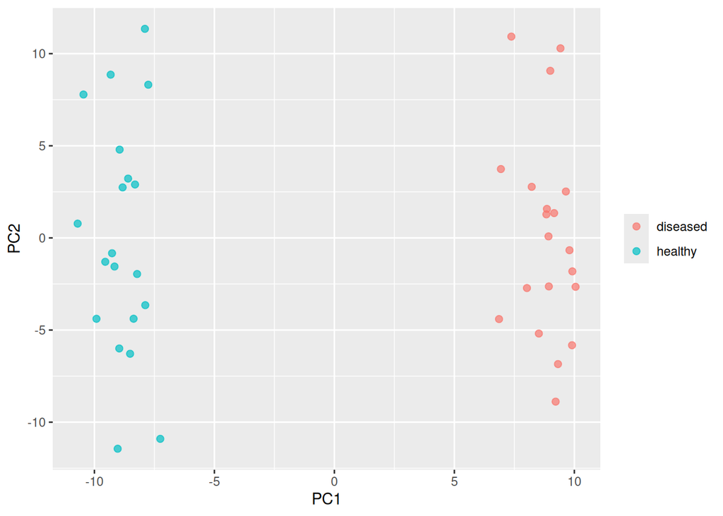

```r
juice(pca_prep) %>%
  ggplot(aes(PC1, PC2)) +
  geom_point(aes(color = group), alpha = 0.7, size = 2) +
  #geom_text(check_overlap = TRUE, hjust = "inward") +
  labs(color = NULL)
```

UMAP

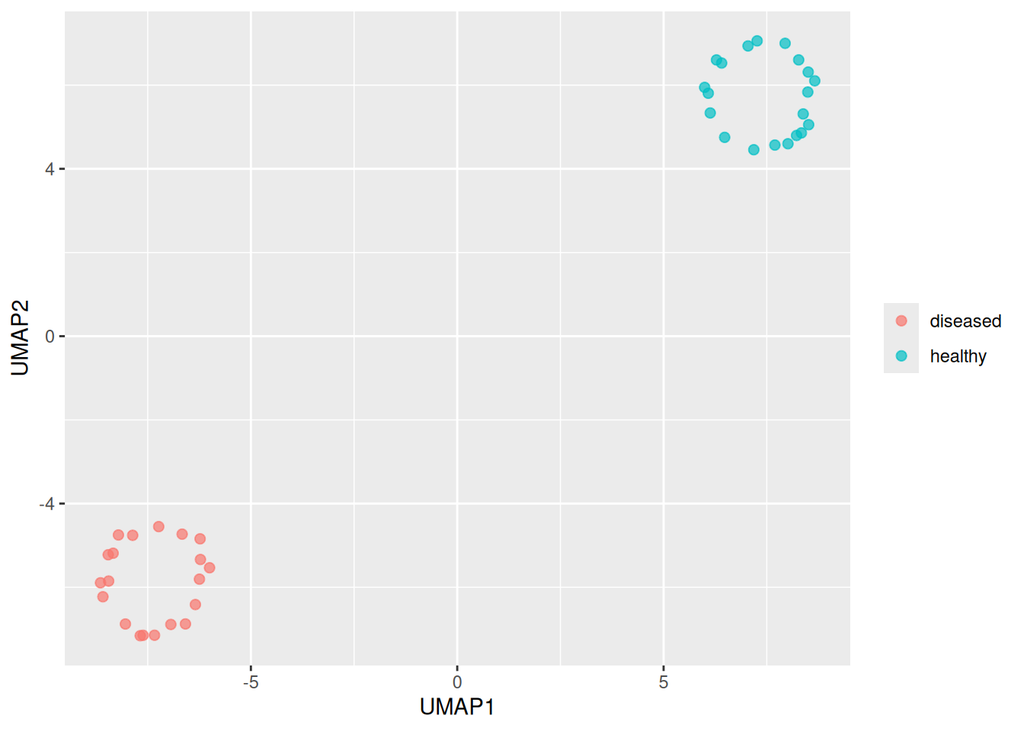

```r
library(embed)
umap_rec <- recipe(~., data = transposed_gene) |>
  update_role(group, new_role = "id") |>
  step_normalize(all_predictors()) |>
  step_umap(all_predictors())
umap_prep <- prep(umap_rec)
umap_prep

juice(umap_prep) %>%
  ggplot(aes(UMAP1, UMAP2)) +
  geom_point(aes(color = group), alpha = 0.7, size = 2) +
#  geom_text(check_overlap = TRUE, hjust = "inward") +
  labs(color = NULL)
```

### 2.3 12.6.13 (c) (30 pts)

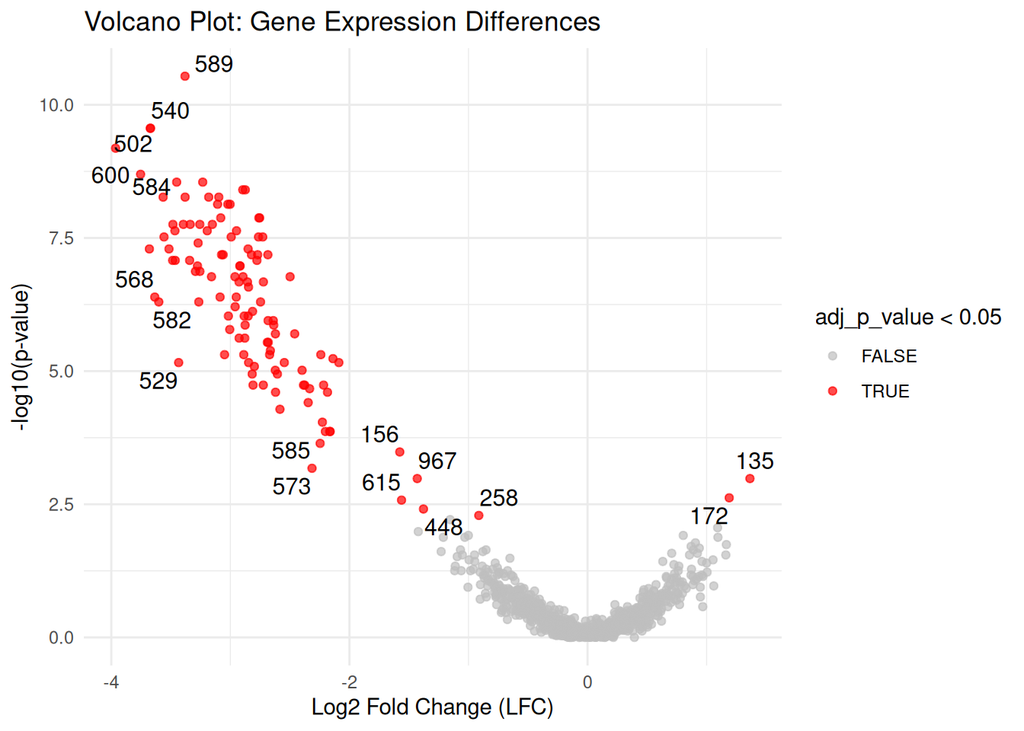

```r
library(ggrepel)

# Read the dataset
Ch12Ex13 <- read_csv("https://www.statlearning.com/s/Ch12Ex13.csv", col_names = paste("ID", 1:40, sep = ""))

# Define group variables (1 = diseased, 0 = healthy)
grp <- factor(rep(c(1, 0), each = 20))

# **Optimized computation of Wilcoxon p-values**
wilcox_pvalues <- apply(as.matrix(Ch12Ex13), 1, function(y) {
  wilcox.test(y ~ grp)$p.value  # Perform Wilcoxon rank-sum test for each gene
})

# **Optimized computation of Log2 Fold Change (LFC)**
logFC_values <- rowMeans(as.matrix(Ch12Ex13)[, 1:20]) - rowMeans(as.matrix(Ch12Ex13)[, 21:40])  # Compute mean differences
logFC_values <- log2(exp(logFC_values))  # Convert to Log2 Fold Change

# **Create results table**
out <- tibble(
  gene = rownames(Ch12Ex13),  # Assign gene names
  p_value = wilcox_pvalues,  # Store p-values
  logFC = logFC_values  # Store Log2 Fold Change values
) %>%
  mutate(adj_p_value = p.adjust(p_value, method = "BH"))

# **Filter significant genes (adj_p_value < 0.05)**
sig_genes <- out %>% filter(adj_p_value < 0.05)

# **Generate the volcano plot**
ggplot(out, aes(x = logFC, y = -log10(p_value))) +
  geom_point(aes(color = adj_p_value < 0.05), alpha = 0.7) +
  geom_text_repel(data = sig_genes, aes(label = gene), size = 4) +
  scale_color_manual(values = c("gray", "red")) +  # Define color mapping
  labs(title = "Volcano Plot: Gene Expression Differences",
       x = "Log2 Fold Change (LFC)", y = "-log10(p-value)") +
  theme_minimal()  # Apply a minimalistic theme
```

**Methodology**

I applied the Wilcoxon rank-sum test for statistical analysis and calculated the log2 Fold Change (LFC) to measure the direction and magnitude of gene expression changes. The Wilcoxon test is suitable for non-normally distributed data and is used to assess whether gene expression significantly differs between the two groups. I adjusted the p-values using the Benjamini-Hochberg (BH) method to control the false discovery rate (FDR) and selected genes with adj_p_value < 0.05 as significantly differentially expressed genes (DEGs). Finally, I visualized the results using a volcano plot, where the x-axis represents the LFC, and the y-axis represents the -log10(p-value), providing an intuitive way to identify genes with significant expression differences between the two groups.

**Findings and Conclusions**